# Practical Machine Learning Project

Lasmyr Edullantes

August 6, 2019

## Correct Exercise Form through Data Science

The increase in available devices for activity tracking and the neo-culture of the quantified self movement has spurred research on human activity recognition to improve health and lifestyle. This study aims to successfully predict the kind of activity from the given sensor data.

To do this, I will train a simple tree-based model, then improve its accuracy by training a more complex tree model, the Random Forest. The final model will be tuned with 5 fold cross validation. Finally, the better model will be chosen based on accuracy, AUC, and prediction distribution. For this activity we will need the `caret`, `dplyr`, `randomForest` and the `pROC` libraries.

## Preprocessing

Before training, the data needed to be cleaned due to the large occurence of NA values. We drop these rows and other irrelevant rows –namely, the usernames, exported indexes, and timestamps.

```r
# data is read
data <- read.csv("pml-training.csv", na.strings = c("NA", "#DIV/0", ""))
testdata <- read.csv("pml-testing.csv",na.strings = c("NA", "#DIV/0", ""))

summary(data)
```

[output not shown]

[output cut: 313 more lines]

```
##  Min.   :-446.00   Min.   :-1280.0   Min.   :-896.0   Min.   :-973.0
##  1st Qu.:-182.00   1st Qu.: -616.0   1st Qu.:   2.0   1st Qu.: 191.0
##  Median : -39.00   Median : -378.0   Median : 591.0   Median : 511.0
##  Mean   : -55.29   Mean   : -312.6   Mean   : 380.1   Mean   : 393.6
##  3rd Qu.:  26.00   3rd Qu.:  -73.0   3rd Qu.: 737.0   3rd Qu.: 653.0
##  Max.   : 291.00   Max.   :  672.0   Max.   :1480.0   Max.   :1090.0
##
##  classe
##  A:5580
##  B:3797
##  C:3422
##  D:3216
##  E:3607
##
##
```

As we can see from above, there are many NA values that render columns unusable.

```r
# selecting all those with NA values
navals <- data.frame(matrix(ncol = 2, nrow = 0))
for (i in 1:ncol(data)) {
  if(sum(is.na(data[,i]))>0) {
    navals <- rbind(navals, data.frame(sum(is.na(data[,i])), colnames(data)[i]))
  }
}
navalscols <-as.character(navals[,2])
uselesscols <- colnames(data)[grepl("^X|timestamp|window|user|problem", names(data))]
dropcols <- append(navalscols, uselesscols)

# Create Train, Validate, Test data
data_clean<- select(data, -dropcols)
test <- select(testdata, -dropcols)
```

Now that the data is clean we split the train data into train and validate data sets. We will use the `createDataPartision` function from the `caret` package.

```r
inTrain <- createDataPartition(y = data_clean$classe, p=0.7)[[1]]
train <- data_clean[inTrain,]
valid <- data_clean[-inTrain,]
head(train)
```

```
##   roll_belt pitch_belt yaw_belt total_accel_belt gyros_belt_x gyros_belt_y
## 2      1.41       8.07    -94.4                3         0.02         0.00
## 3      1.42       8.07    -94.4                3         0.00         0.00
## 4      1.48       8.05    -94.4                3         0.02         0.00
## 5      1.48       8.07    -94.4                3         0.02         0.02
## 7      1.42       8.09    -94.4                3         0.02         0.00
## 8      1.42       8.13    -94.4                3         0.02         0.00
##   gyros_belt_z accel_belt_x accel_belt_y accel_belt_z magnet_belt_x
## 2        -0.02          -22            4           22            -7
## 3        -0.02          -20            5           23            -2
## 4        -0.03          -22            3           21            -6
## 5        -0.02          -21            2           24            -6
## 7        -0.02          -22            3           21            -4
## 8        -0.02          -22            4           21            -2
##   magnet_belt_y magnet_belt_z roll_arm pitch_arm yaw_arm total_accel_arm
```

[output cut: 69 more lines]

## Modelling

Now models will be made. I chose to focus on tree-based models because of its simplicity and interpretability, as well as its strength in classification. For the first model, a simple decision tree will be made.

**Decision Tree**

```r
# Simple Decision Tree
model_simple <- train(classe ~ ., data = train, method = "rpart")
pred1 <- predict(model_simple, newdata = valid)
pred1_proba <- predict(model_simple, newdata = valid, type = "prob")
confusionMatrix(pred1, valid$classe)
```

```
## Confusion Matrix and Statistics
##
##           Reference
## Prediction    A    B    C    D    E
##          A 1517  462  504  439  138
##          B   38  400   28  178  167
##          C  117  277  494  347  274
##          D    0    0    0    0    0
##          E    2    0    0    0  503
##
## Overall Statistics
##
##                Accuracy : 0.4952
##                  95% CI : (0.4823, 0.508)
##     No Information Rate : 0.2845
##     P-Value [Acc > NIR] : < 2.2e-16
##
##                   Kappa : 0.34
##  Mcnemar's Test P-Value : NA
##
## Statistics by Class:
##
##                      Class: A Class: B Class: C Class: D Class: E
## Sensitivity            0.9062  0.35119  0.48148   0.0000  0.46488
## Specificity            0.6336  0.91340  0.79111   1.0000  0.99958
## Pos Pred Value         0.4958  0.49322  0.32737      NaN  0.99604
## Neg Pred Value         0.9444  0.85436  0.87843   0.8362  0.89238
## Prevalence             0.2845  0.19354  0.17434   0.1638  0.18386
## Detection Rate         0.2578  0.06797  0.08394   0.0000  0.08547
## Detection Prevalence   0.5200  0.13781  0.25641   0.0000  0.08581
## Balanced Accuracy      0.7699  0.63229  0.63630   0.5000  0.73223
```

```r
auc1 <- multiclass.roc(pred1_proba$A, as.numeric(valid$classe))
auc1
```

```
##
## Call:
## multiclass.roc.default(response = pred1_proba$A, predictor = as.numeric(valid$classe))
##
## Data: as.numeric(valid$classe) with 5 levels of pred1_proba$A: 0.0105263157894737, 0.0359314538419016, 0.0769022474952613, 0.408248455501753, 0.994575045207956.
## Multi-class area under the curve: 0.8093
```

As can be seen, the simple decision tree is not so great at predicting activity. To improve this, we will try a tuned Random Forest model.

**Random Forest**

```r
# Tuned Random Forest
controlRf <- trainControl(method="cv", 5)
model_complex <- train(classe ~., data = train,
                       method="rf", trControl=controlRf,
                       importance=TRUE, ntree=100)
pred2 <- predict(model_complex, newdata = valid)
pred2_proba <- predict(model_complex, newdata = valid, type = "prob")
confusionMatrix(pred2, valid$classe)
```

```
## Confusion Matrix and Statistics
##
##           Reference
## Prediction    A    B    C    D    E
##          A 1670    5    0    0    0
##          B    2 1129    3    0    0
##          C    2    5 1017    7    5
##          D    0    0    6  956    4
##          E    0    0    0    1 1073
##
## Overall Statistics
##
##                Accuracy : 0.9932
##                  95% CI : (0.9908, 0.9951)
##     No Information Rate : 0.2845
##     P-Value [Acc > NIR] : < 2.2e-16
##
##                   Kappa : 0.9914
##  Mcnemar's Test P-Value : NA
##
## Statistics by Class:
##
##                      Class: A Class: B Class: C Class: D Class: E
## Sensitivity            0.9976   0.9912   0.9912   0.9917   0.9917
## Specificity            0.9988   0.9989   0.9961   0.9980   0.9998
## Pos Pred Value         0.9970   0.9956   0.9817   0.9896   0.9991
## Neg Pred Value         0.9990   0.9979   0.9981   0.9984   0.9981
## Prevalence             0.2845   0.1935   0.1743   0.1638   0.1839
## Detection Rate         0.2838   0.1918   0.1728   0.1624   0.1823
## Detection Prevalence   0.2846   0.1927   0.1760   0.1641   0.1825
## Balanced Accuracy      0.9982   0.9951   0.9937   0.9948   0.9957
```

```r
auc2<-multiclass.roc(pred2_proba$A, as.numeric(valid$classe))
auc2
```

```
##
## Call:
## multiclass.roc.default(response = pred2_proba$A, predictor = as.numeric(valid$classe))
##
## Data: as.numeric(valid$classe) with 84 levels of pred2_proba$A: 0, 0.01, 0.02, 0.03, 0.04, 0.05, 0.06, 0.07, 0.08, 0.09, 0.1, 0.11, 0.12, 0.13, 0.14, 0.15, 0.16, 0.17, 0.18, 0.19, 0.2, 0.21, 0.22, 0.23, 0.24, 0.25, 0.26, 0.27, 0.28, 0.29, 0.3, 0.32, 0.33, 0.36, 0.37, 0.39, 0.43, 0.44, 0.45, 0.47,…
## Multi-class area under the curve: 0.7615
```

To further compare the two models, we can see how the predictions are distributed. The closer to the train data they are distributed, the better.

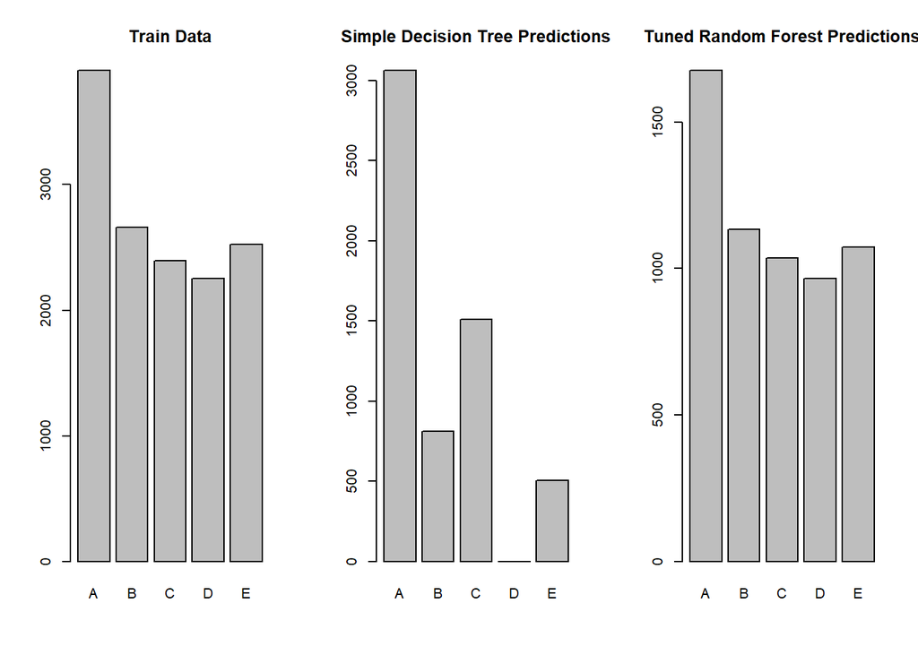

As can be seen above, the random forest follows the distribution of the train data more than the simple decision tree. It is decided then that we will use the random forest to predict the test set.

**Test Predictions**

```r
test_pred <- predict(model_complex, newdata = test)
test_pred_proba <- predict(model_complex, newdata = test, type = "prob")
test_pred_result <- data.frame(test_pred, test_pred_proba)
colnames(test_pred_result) <- c("prediction", "probability")
head(test_pred_result)
```

```
##   prediction probability   NA   NA   NA   NA
## 1          B        0.03 0.81 0.10 0.02 0.04
## 2          A        1.00 0.00 0.00 0.00 0.00
## 3          B        0.09 0.80 0.08 0.00 0.03
## 4          A        0.94 0.00 0.05 0.01 0.00
## 5          A        0.97 0.01 0.00 0.00 0.02
## 6          E        0.01 0.02 0.04 0.01 0.92
```

Since we don’t have the response to validate the test set, we will just check if the distribution of the test predictions is similar to the validate set of the random forest, and the train data.

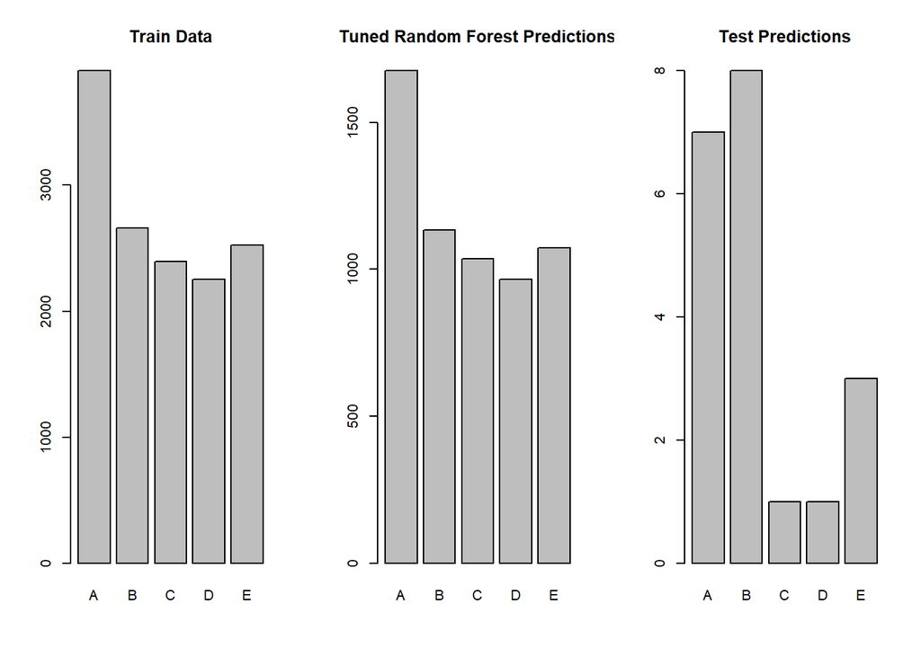